# **data simulations**

andrés castro araújo

2019-08-25

## Amusement Park Data

> In this section, we simulate data for a hypothetical survey of visitors to an amusement park. This data set comprises a few objective measures: whether the respondent visited on a weekend (which will be the variable `weekend` in the data frame), the number of children brought (`num_child`), and distance traveled to the park (`distance`).

> Our hypothetical survey includes four questions about a customer’s satisfaction with different dimensions of a visit to the amusement park: satisfaction with rides (`rides`), games (`games`), waiting times (`wait`), and cleanliness (`clean`), along with a rating of overall satisfaction (`overall`). In such surveys, respondents often answer similarly on all satisfaction questions; this is known as the *halo effect* (Chapman and Feit 2019).

```r
set.seed(12345)
nresp <- 500 ## number of respondents
halo <- rnorm(n = nresp , mean = 0, sd = 5)

rides <- floor(rnorm(n = nresp, mean = 80, sd = 3)) + halo
games <- floor(rnorm(n = nresp, mean = 70, sd = 7)) + halo
wait  <- floor(rnorm(n = nresp, mean = 65, sd = 10)) + halo
clean <- floor(rnorm(n = nresp, mean = 85, sd = 2)) + halo
```

By adding `halo` to the response for each question, we create positive correlation between the responses.

```r
cor(tibble(rides, games, wait, clean))
```

```
          rides     games      wait     clean
rides 1.0000000 0.5222500 0.3605823 0.7960632
games 0.5222500 1.0000000 0.2612434 0.5713837
wait  0.3605823 0.2612434 1.0000000 0.3581697
clean 0.7960632 0.5713837 0.3581697 1.0000000
```

Note that we have the same means, but different standard deviations because the sum of two normals has a standard deviation of $\sqrt{\sigma_1^2 + \sigma_2^2}$

```r
tibble(rides, games, wait, clean) %>%
    summarise_all(stats::sd)
```

```
# A tibble: 1 x 4
  rides games  wait clean
  <dbl> <dbl> <dbl> <dbl>
1  5.80  8.89  11.1  5.23
```

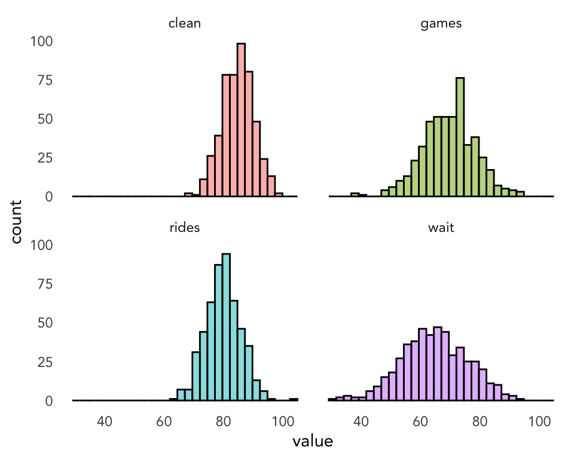

```r
tibble(rides, games, wait, clean) %>%
  gather() %>%
  ggplot(aes(x = value, fill = key)) +
  geom_histogram(color = "black", alpha = 0.5, show.legend = FALSE, bins = 30) +
  facet_wrap(~key)
```

> Satisfaction surveys often include other questions related to the customer experience. For the amusement park data, we include whether the visit was on a weekend, how far the customer traveled to the park in miles, and the number of children in the party. We generate this data using two functions: `rlnorm()` to sample a log-normal distribution for `distance`, and `sample()` to sample discrete distributions for `weekend` and number of children (`num_child`)

```r
set.seed(12345)
distance <- rlnorm(n = nresp, meanlog = 3, sdlog = 1)
num_child <- sample(
  x = 0:5, size = nresp, replace = TRUE,
  prob = c(0.3, 0.15, 0.25, 0.15, 0.1, 0.05)
)
weekend <- as.factor(sample(
  x = c("yes", "no"), size = nresp, replace = TRUE,
  prob = c(0.5, 0.5)
))
```

> We create the overall satisfaction rating as a function of ratings for the various aspects of the visit (satisfaction with rides, cleanliness, and so forth), distance traveled, and the number of children.

```r
set.seed(12345)
## Note, these are the parameters we should estimate from linear regression
overall <- floor(halo + 0.5 * rides + 0.1 * games + 0.3 * wait + 0.2 * clean +
  0.03 * distance + 5 * (num_child == 0) + 0.3 * wait * (num_child > 0) +
  rnorm(n = nresp, mean = 0, sd = 7))

k <- (100 - max(overall))
overall <- overall + k

df <- tibble(overall, rides, games, wait, clean, distance, num_child, weekend)
```

We can also generate the halo effect differently, by simulating the satisfaction questions’ correlation matrix.

```r
nresp <- 500 ## number of respondents

mus <- c(rides = 80, games = 70, wait = 65, clean = 85)
sds <- c(rides = 3, games = 7, wait = 10, clean = 2)
sds <- sqrt(sds^2 + 5^2) ## this ensures our two simulations are similar

corr_matrix <- array(data = NA, dim = c(4, 4))

for (i in 2:4) {
  for (j in 1:(i - 1)) {  ## the halo becomes "structure" in the correlation matrix
    corr_matrix[i, j] <- runif(1, min = 0.3, max = 1)
  }
}

corr_matrix[upper.tri(corr_matrix)] <- t(corr_matrix)[upper.tri(corr_matrix)]
diag(corr_matrix) <- 1

# Compute the nearest positive definite matrix to an approximate one, simulating
# correlation matrices is not easy!
corr_matrix <- Matrix::nearPD(corr_matrix, corr = TRUE)$mat %>% as.matrix()
cov_matrix <- diag(sds) %*% corr_matrix %*% diag(sds)

simulation <- mvtnorm::rmvnorm(n = nresp, mus, cov_matrix)
```

```r
readr::write_rds(df, "apd.rds", compress = "gz")
```

## Conjoint Choice Data

> The park is now considering designs for a new roller coaster and hopes to find out which roller coaster features appeal to its customers. They are considering coasters with various possible levels of maximum `speed` (40, 50, 60 or 70 mph), `height` (200, 300, or 400 feet), `construction` type (wood or steel), and `theme` (dragon or eagle). The stakeholders wish to know which combination of features would be most popular according to customers’ stated preference.

## References

Chapman, Chris, and Elea McDonnell Feit. 2019. *R for Marketing Research and Analytics*. Springer.